# Assignment 6: Visualization - Aesthetic Mapping

*How to do it?*:

- Open the Rmarkdown file of this assignment (link) in Rstudio.
- Right under each **question**, insert a code chunk (you can use the hotkey `Ctrl + Alt + I` to add a code chunk) and code the solution for the question.
- `Knit` the rmarkdown file (hotkey: `Ctrl + Alt + K`) to export an html.
- Publish the html file to your Githiub Page.

*Submission*: Submit the link on Github of the assignment to Canvas.

### Questions on Your Selected Data

Choose a dataset and produce the following types of plots and comment on each plot. Plots should be meaningful. If you use the data we used in class, make sure the plots are not the same as the ones in the slides.

```r
library(tidyverse)

df <- read_csv('C:/Users/student/Documents/R/Math421/cancer patient data sets.csv')


head(df)
```

```
## # A tibble: 6 x 25
##   `Patient Id`   Age Gender `Air Pollution` `Alcohol use` `Dust Allergy`
##   <chr>        <dbl>  <dbl>           <dbl>         <dbl>          <dbl>
## 1 P1              33      1               2             4              5
## 2 P10             17      1               3             1              5
## 3 P100            35      1               4             5              6
## 4 P1000           37      1               7             7              7
## 5 P101            46      1               6             8              7
## 6 P102            35      1               4             5              6
## # ... with 19 more variables: OccuPational Hazards <dbl>, Genetic Risk <dbl>,
## #   chronic Lung Disease <dbl>, Balanced Diet <dbl>, Obesity <dbl>,
## #   Smoking <dbl>, Passive Smoker <dbl>, Chest Pain <dbl>,
## #   Coughing of Blood <dbl>, Fatigue <dbl>, Weight Loss <dbl>,
## #   Shortness of Breath <dbl>, Wheezing <dbl>, Swallowing Difficulty <dbl>,
## #   Clubbing of Finger Nails <dbl>, Frequent Cold <dbl>, Dry Cough <dbl>,
## #   Snoring <dbl>, Level <chr>
```

1. For one continuous variable (I will be using Age):
- Density

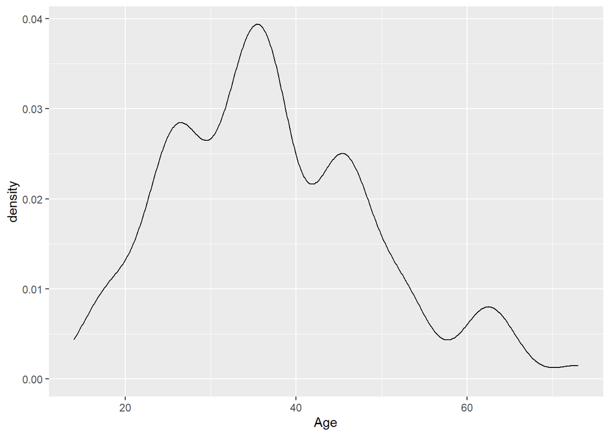

```r
df %>% ggplot()+
  geom_density(mapping = aes(x = Age))
```

- Histogram

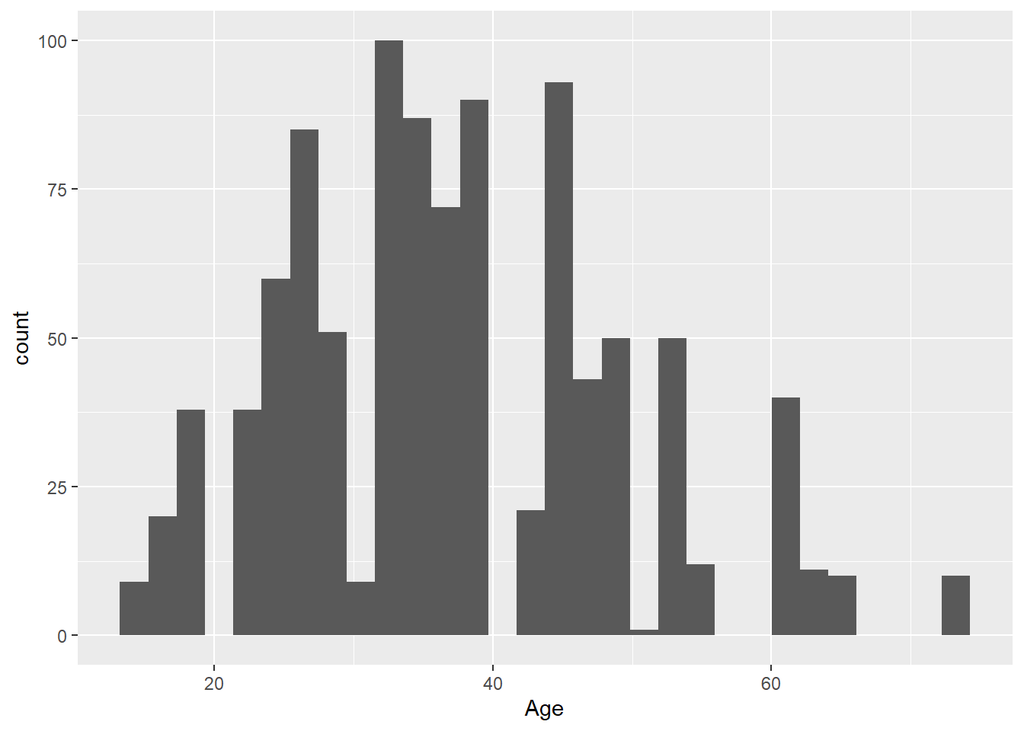

```r
df %>% ggplot()+
  geom_histogram(mapping = aes(x = Age))
```

- Boxplot

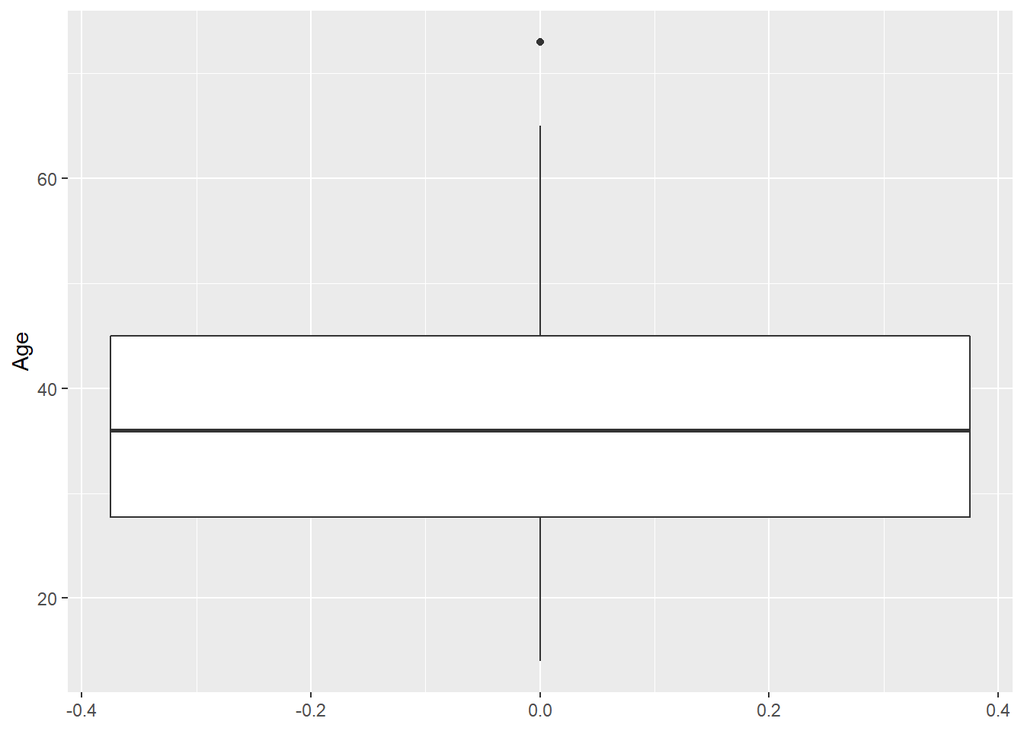

```r
df %>% ggplot()+
  geom_boxplot(mapping = aes(y = Age))
```

2. For one categorical variable
- Barplot

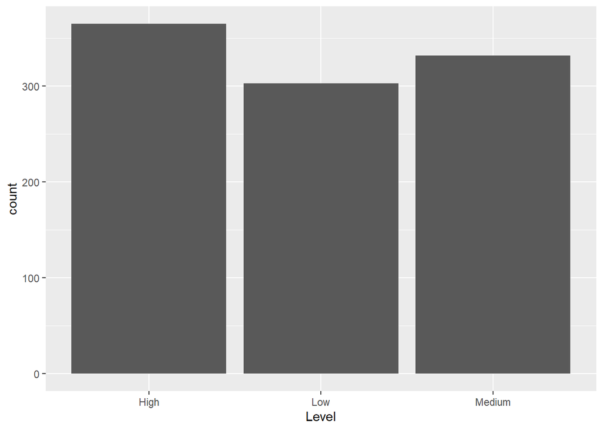

```r
df %>% ggplot()+
  geom_bar(mapping = aes(x = Level))
```

```r
names(df)
```

```
##  [1] "Patient Id"               "Age"
##  [3] "Gender"                   "Air Pollution"
##  [5] "Alcohol use"              "Dust Allergy"
##  [7] "OccuPational Hazards"     "Genetic Risk"
##  [9] "chronic Lung Disease"     "Balanced Diet"
## [11] "Obesity"                  "Smoking"
## [13] "Passive Smoker"           "Chest Pain"
## [15] "Coughing of Blood"        "Fatigue"
## [17] "Weight Loss"              "Shortness of Breath"
## [19] "Wheezing"                 "Swallowing Difficulty"
## [21] "Clubbing of Finger Nails" "Frequent Cold"
## [23] "Dry Cough"                "Snoring"
## [25] "Level"
```

3. For one two continuous variables
- Scatter Plot

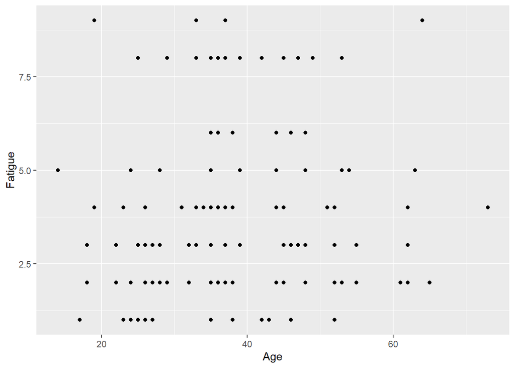

```r
df%>% ggplot()+
  geom_point(mapping = aes(x = Age, y = Fatigue))
```

- Line Plot

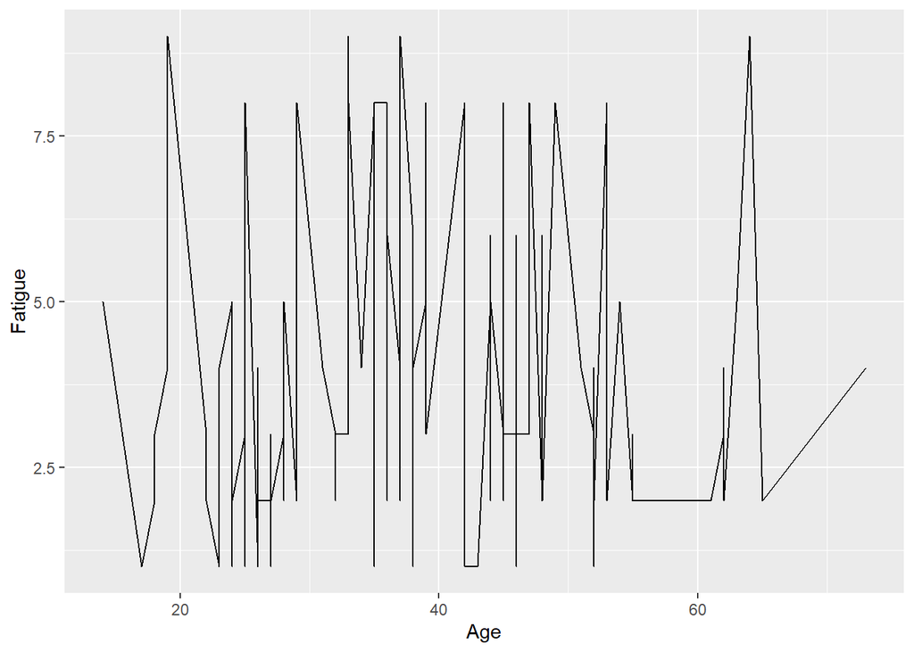

```r
df%>% ggplot()+
  geom_line(mapping = aes(x = Age, y = Fatigue))
```

- Smooth Plot

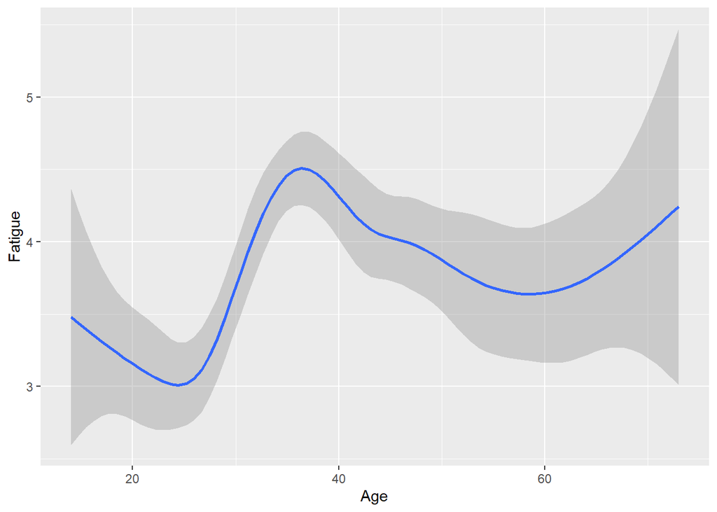

```r
df%>% ggplot()+
  geom_smooth(mapping = aes(x = Age, y = Fatigue))
```

4. For one continuous + one categorical variables
- Density

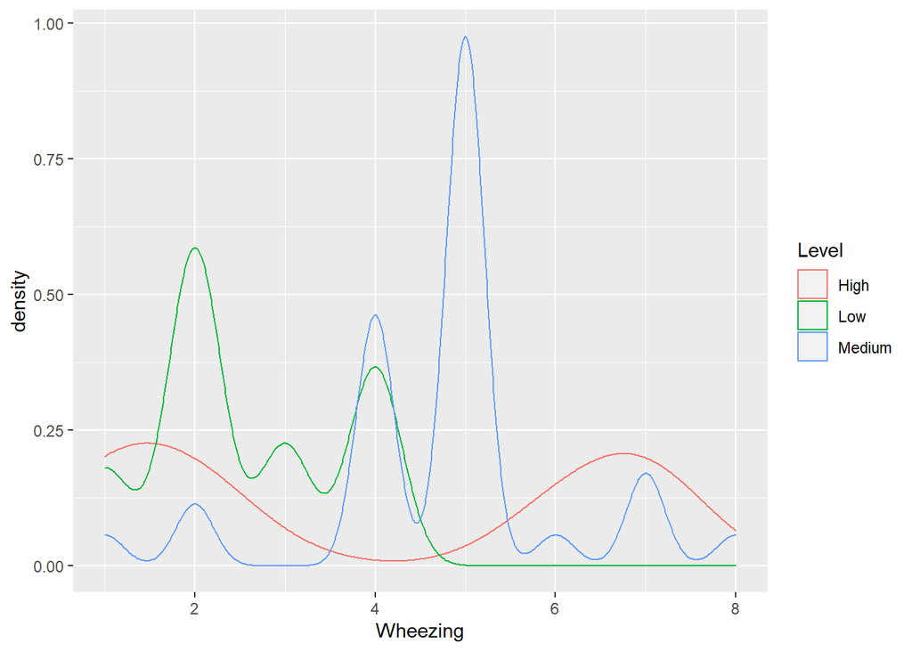

```r
df %>% ggplot()+
  geom_density(mapping = aes(x = Wheezing, color = Level))
```

- BoxPlot

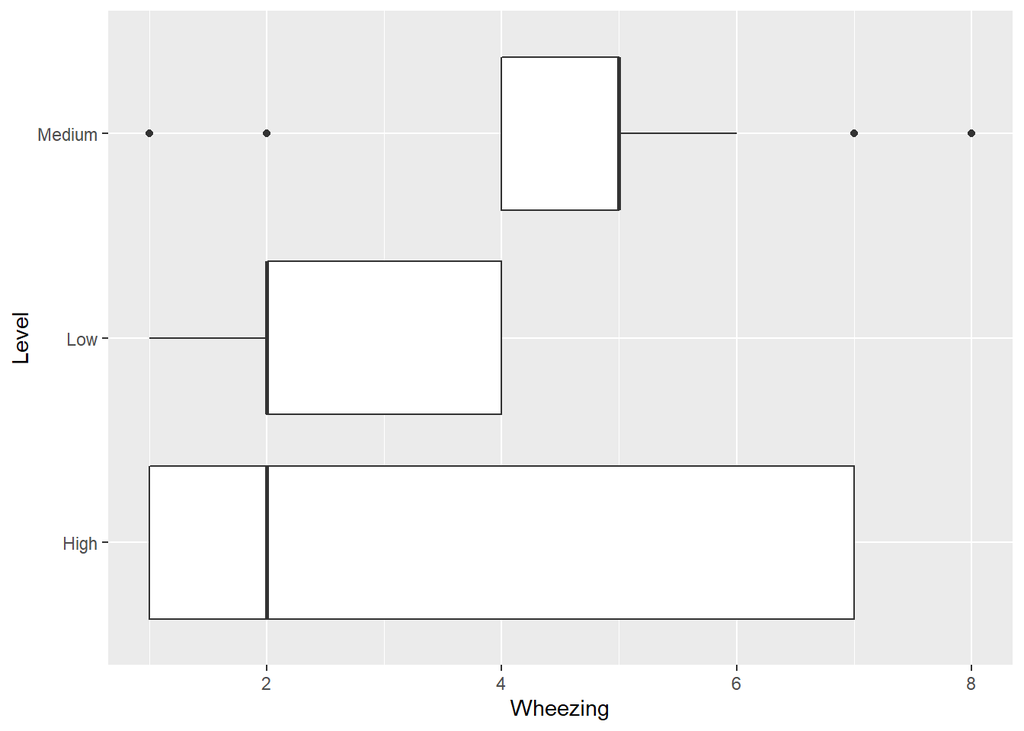

```r
df  %>% ggplot()+
  geom_boxplot(mapping = aes(x = Wheezing, y = Level))
```

5. For two categorical variables: barplot

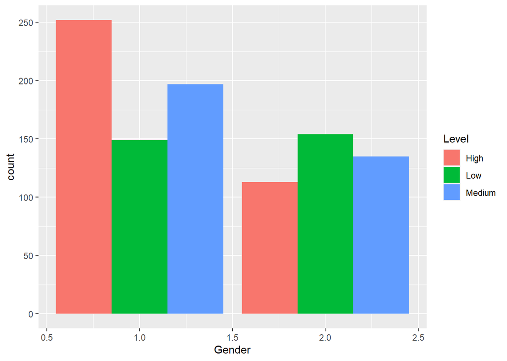

```r
df %>% ggplot()+
  geom_bar(mapping=aes(x=Gender, fill=Level), position='dodge')
```

### Questions on Covid Vaccination Data

In this section of questions, we will use the covid vaccination data for the US. The data and data dictionary can be found at the below link:

- [Data](https://raw.githubusercontent.com/govex/COVID-19/master/data_tables/vaccine_data/us_data/time_series/vaccine_data_us_timeline.csv)
- [Data Dictionary](https://github.com/govex/COVID-19/blob/master/data_tables/vaccine_data/us_data/data_dictionary.csv)

```r
library(tidyverse)
df <- read_csv('https://raw.githubusercontent.com/govex/COVID-19/master/data_tables/vaccine_data/us_data/time_series/vaccine_data_us_timeline.csv')
```

1. `Geom_point` makes scatter plots, which plot two numeric (or Date) variables. A third categorical variable is often brought in for color. For example, we can compare different vaccine types in Rhode Island by

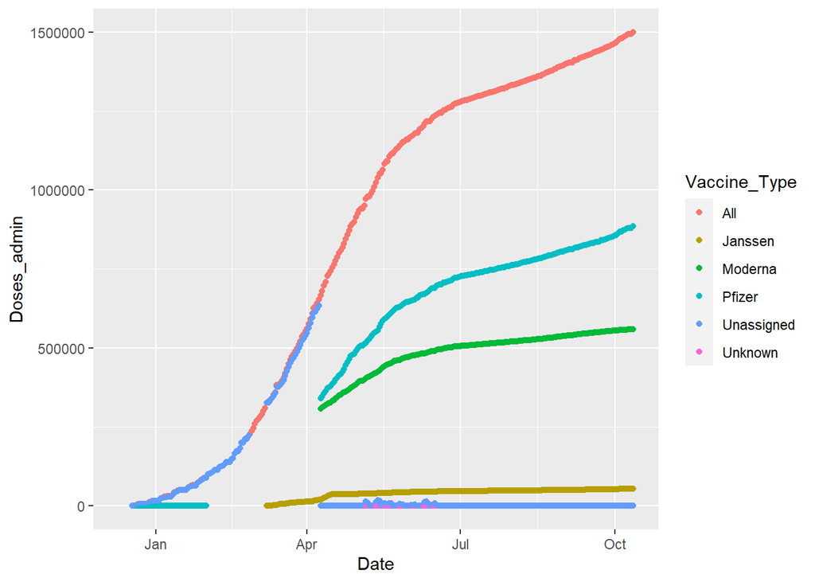

```r
df %>% filter(Province_State=='Rhode Island') %>% ggplot()+geom_point(mapping = aes(x = Date, y = Doses_admin, color = Vaccine_Type))
```

Do the follows.

- Use `geom_point` to compare the the Moderna and Pfizer vaccine administered in California

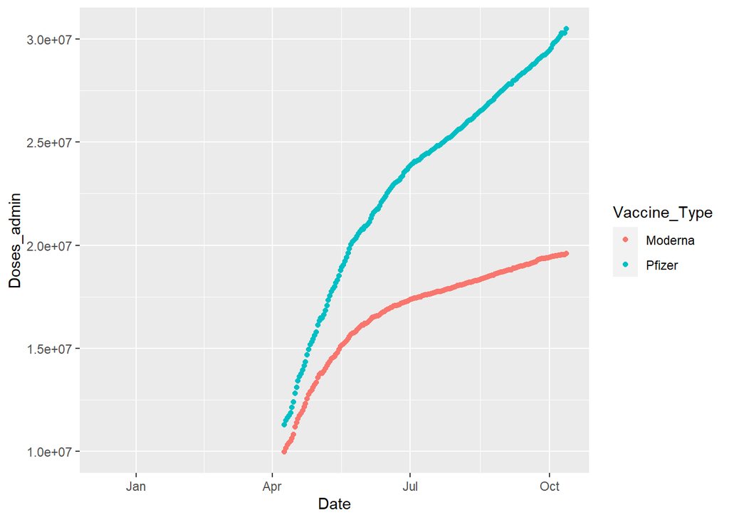

```r
df %>% filter(Province_State == "California", Vaccine_Type %in% c("Pfizer","Moderna")) %>% ggplot() + geom_point(mapping = aes(x = Date, y = Doses_admin, color = Vaccine_Type))
```

- Use `geom_point` to compare the total vaccine administered in Rhode Island and Massachusetts

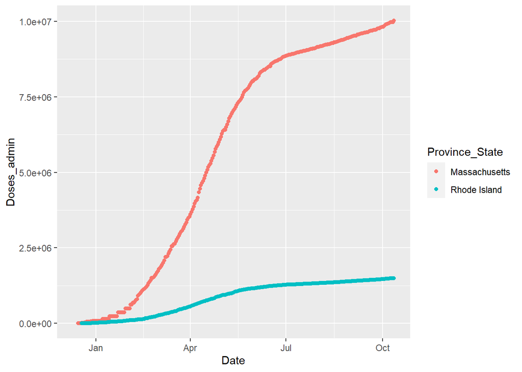

```r
df %>% filter((Province_State=='Rhode Island'|Province_State=='Massachusetts'), Vaccine_Type=='All') %>% ggplot()+
  geom_point(mapping = aes(x = Date, y = Doses_admin, color = Province_State))
```

- Change `geom_point` to `geom_line` in the above codes to have the corresponding line plots.

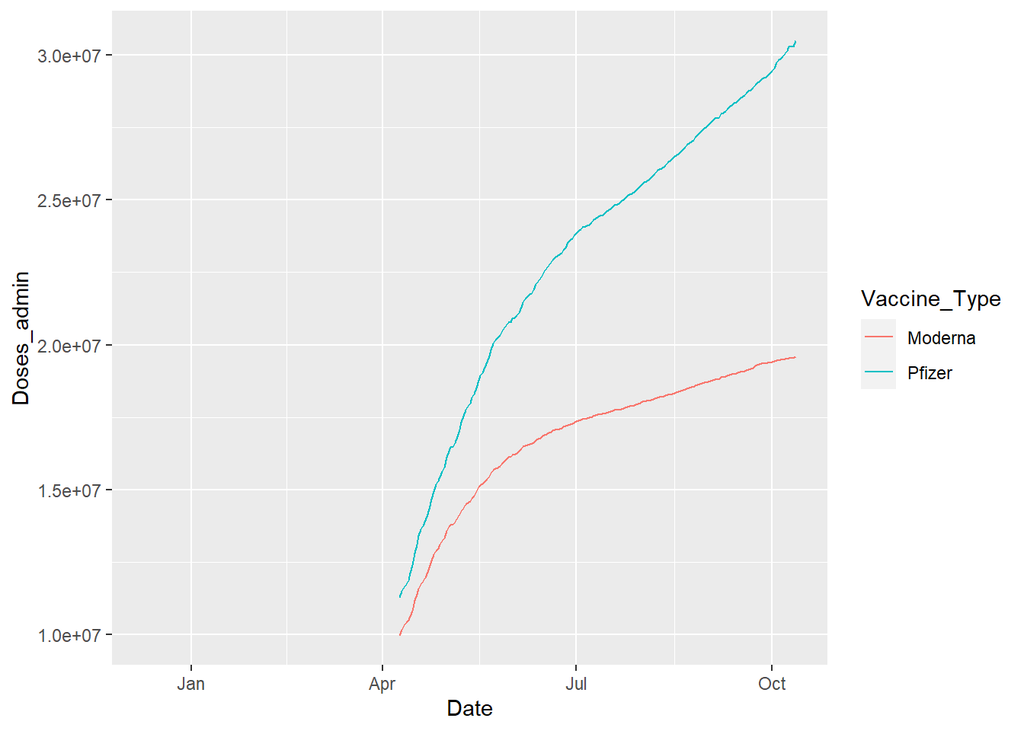

```r
df %>% filter(Province_State == "California", Vaccine_Type %in% c("Pfizer","Moderna")) %>% ggplot() + geom_line(mapping = aes(x = Date, y = Doses_admin, color = Vaccine_Type))
```

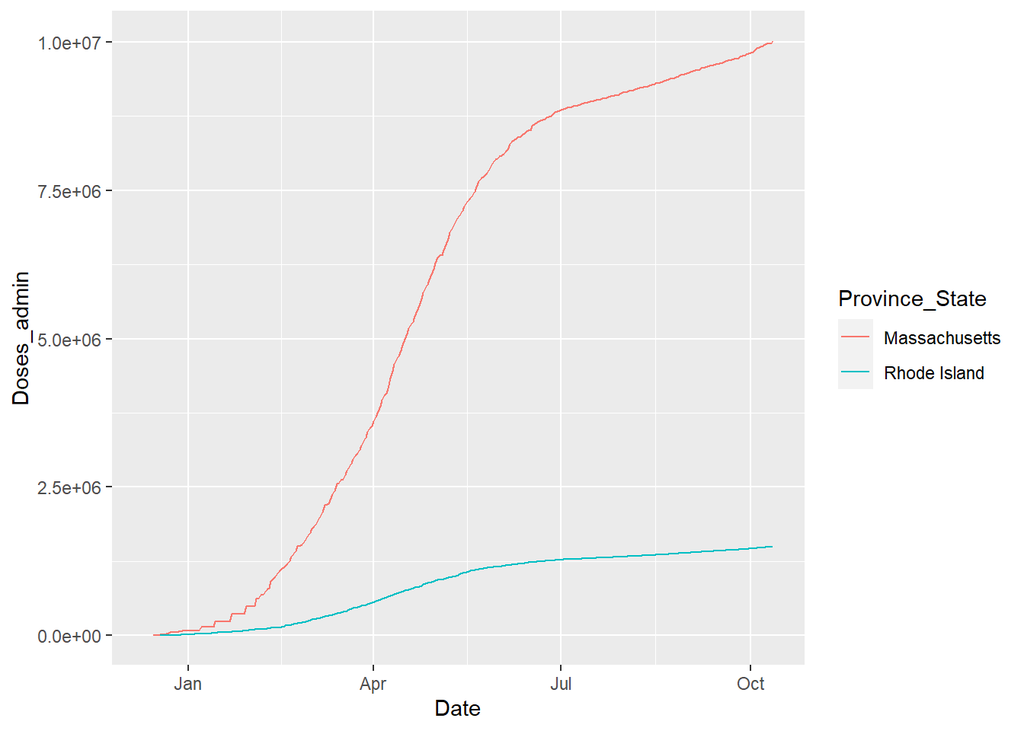

```r
df %>% filter((Province_State=='Rhode Island'|Province_State=='Massachusetts'), Vaccine_Type=='All') %>% ggplot()+
  geom_line(mapping = aes(x = Date, y = Doses_admin, color = Province_State))
```

2. Sometime we need to do some calculations on the data before plotting. For example, to compare the popularity of two vaccine `Moderna` and `Pfizer` by date, we can use.

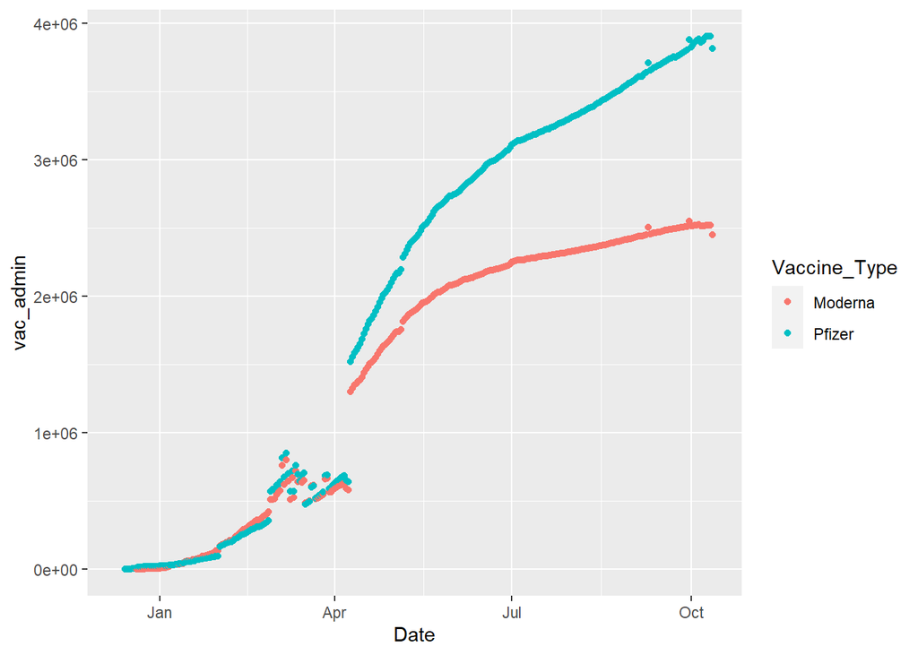

```r
# Create a dataset recording these two vaccine administered by date
d1 <- df %>% filter(Vaccine_Type==c('Moderna','Pfizer')) %>% group_by(Date, Vaccine_Type) %>% summarise(vac_admin=mean(Doses_admin, na.rm=TRUE))

# Plot from the newly create data
d1 %>% ggplot()+geom_point(mapping=aes(x=Date, y=vac_admin, color=Vaccine_Type))
```

Do the follows.

- Use `geom_point` to compare the popularity of all vaccines by date.

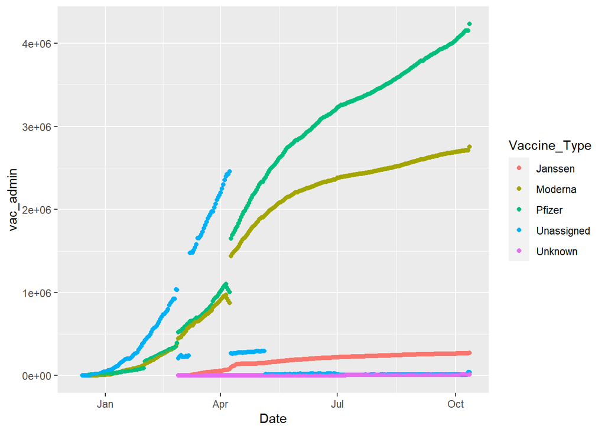

```r
# Create a dataset recording these two vaccine administered by date
d2 <- df %>% filter(Vaccine_Type!=('All')) %>% group_by(Date, Vaccine_Type) %>% summarise(vac_admin=mean(Doses_admin, na.rm=TRUE))

# Plot from the newly create data
d2 %>% ggplot()+geom_point(mapping=aes(x=Date, y=vac_admin, color=Vaccine_Type))
```

- Use `geom_line` to compare the popularity of all vaccines in New England by date.

```r
# Create a dataset recording these two vaccine administered by date
d2 <- df %>% filter(Vaccine_Type!=('All'), Province_State == c("Rhode Island", "Maine", "New Hampshire", "Massachusetts", "Connecticut", "Vermont")) %>% group_by(Date, Vaccine_Type) %>% summarise(vac_admin=mean(Doses_admin, na.rm=TRUE))
```

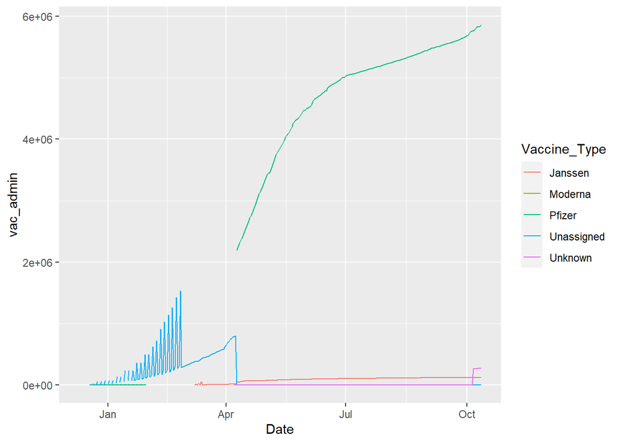

```r
# Plot from the newly create data
d2 %>% ggplot()+geom_line(mapping=aes(x=Date, y=vac_admin, color=Vaccine_Type))
```

```r
library(lubridate)
df$Month <-  factor(month(df$Date, label = TRUE))

d2 <- df%>% filter(Vaccine_Type!=('All'), Province_State == c("Rhode Island", "Maine", "New Hampshire", "Massachusetts", "Connecticut", "Vermont")) %>% group_by(Vaccine_Type, Month) %>% summarise(doses = mean(Doses_admin))
```

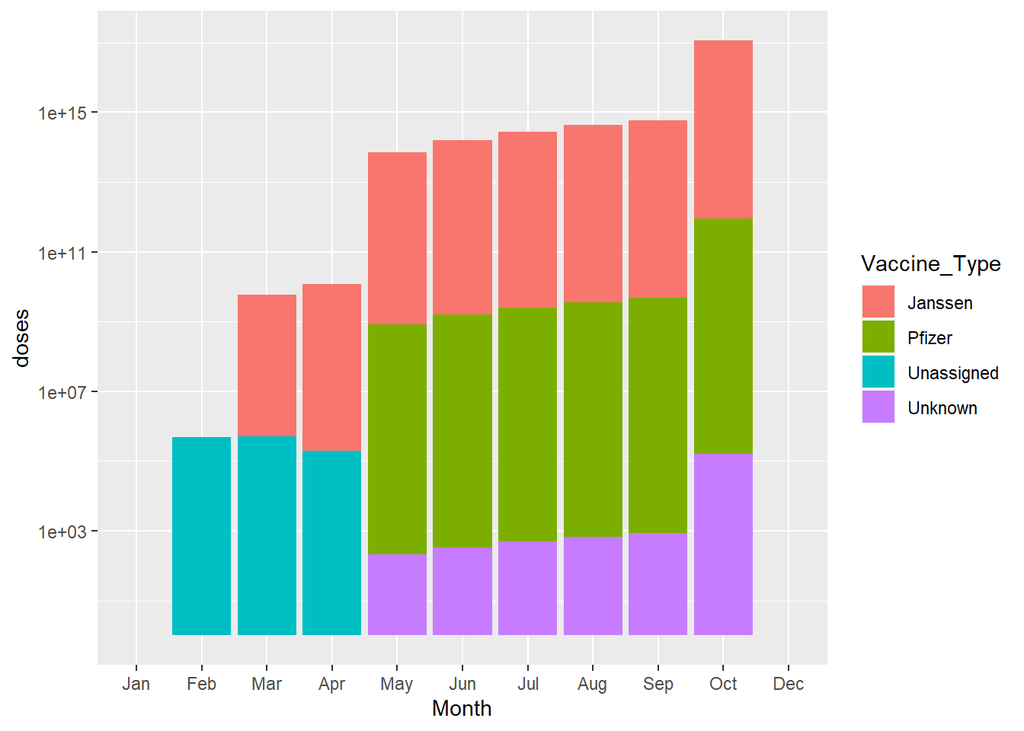

```r
# Plot from the newly create data
d2 %>% ggplot()+geom_col(mapping=aes(x=Month, y=doses, fill=Vaccine_Type))+scale_y_log10()
```

- Use `geom_line` to compare states in New England in term of the total vaccine administered by date.

```r
# Create a dataset recording these two vaccine administered by state in ne
d2 <- df %>% filter(Vaccine_Type!=('All'), Province_State == c("Rhode Island", "Maine", "New Hampshire", "Massachusetts", "Connecticut", "Vermont"))%>% group_by(Date, Province_State) %>% summarise(vac_admin=mean(Doses_admin, na.rm=TRUE))
```

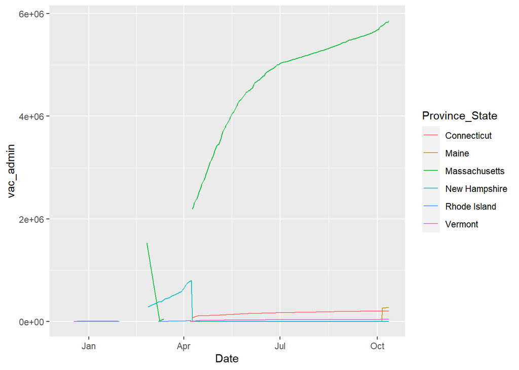

```r
# Plot from the newly create data
d2 %>% ggplot()+geom_line(mapping=aes(x=Date, y=vac_admin, color=Province_State))
```